# Ensemble methods

- 통상적인 머신러닝 알고리즘(선형회귀, 로지스틱회귀, 의사결정나무 등)의 문제점
  - Training variance
    - 학습데이터에 약간의 변화가 생겨도 예측 결과가 심하게 달라지는 문제
    - 배깅, 부스팅, 랜덤포레스트와 같은 앙상블 방법을 통해 해결
  - Linearly inseparable data
    - 학습하고자 하는 시스템이 선형이 아닌 경우가 많음
    - SVM과 같은 커널 방법이 대안

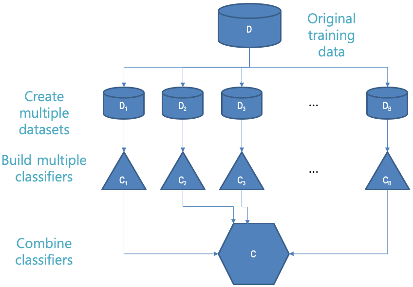

## 9.1 Ensemble method: Bagging(or bootstrap aggregation)

- 배깅의 일반 절차
  1. Draw bootstrap samples from your data.
  2. From each bootstrap sample, build a decision tree model.
  3. The final model is the average of all the individual decision trees.

#### Example: Spambase data

```r
loglikelihood <- function(y, py) {
  pysmooth <- ifelse(py == 0, 1e-12,
                     ifelse(py == 1, 1 - 1e-12, py))
  sum(y*log(pysmooth) + (1 - y)*log(1 - pysmooth))
}

accuracyMeasures <- function(pred, truth, name = "model") {
  dev.norm <- -2*loglikelihood(as.numeric(truth), pred)/length(pred)
  ctable <- table(truth = truth,
                  pred = (pred > 0.5))  # cutoff = 0.5
  print(ctable)
  accuracy <- sum(diag(ctable))/sum(ctable)
  precision <- ctable[2,2]/sum(ctable[,2])
  recall <- ctable[2,2]/sum(ctable[2,])
  f1 <- precision*recall
  data.frame(model = name, accuracy = accuracy, f1 = f1, dev.norm)
}
```

- Decision tree

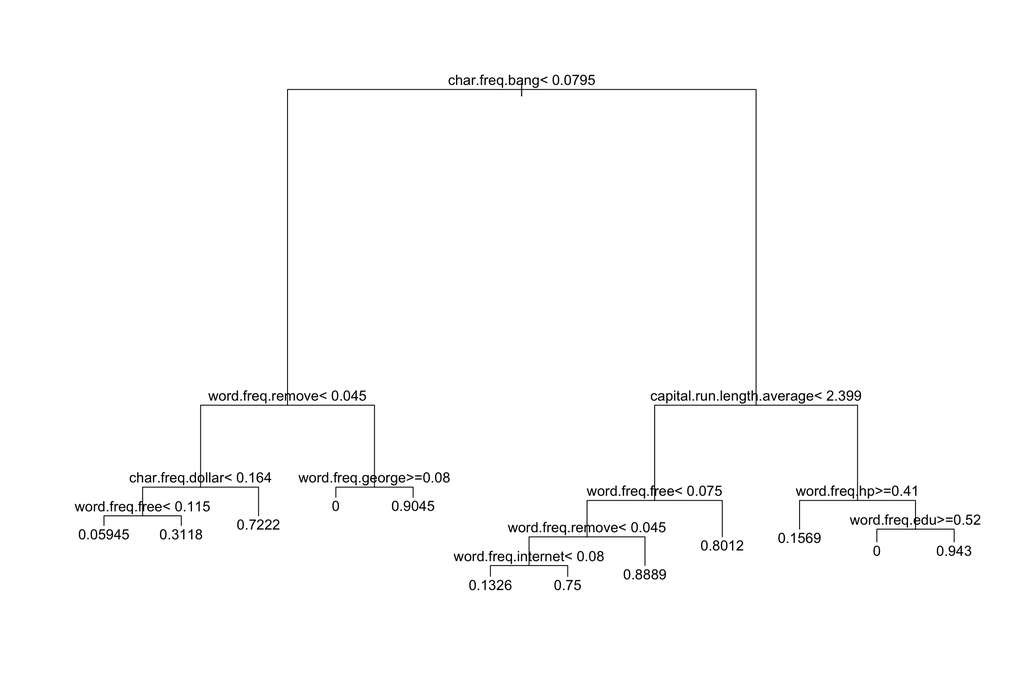

```r
spamD <- read.table('./dat/spamD.tsv', header = TRUE, sep = '\t')
#spamD <- read.table('https://raw.githubusercontent.com/WinVector/zmPDSwR/master/Spambase/spamD.tsv', header = TRUE, sep = '\t')

spamTrain <- subset(spamD, spamD$rgroup >= 10)
spamTest <- subset(spamD, spamD$rgroup < 10)

spamVars <- setdiff(colnames(spamD), list('rgroup', 'spam'))
spamFormula <- as.formula(paste('spam == "spam"',
                                paste(spamVars, collapse=' + '),
                                sep=' ~ '))

library(rpart)

treemodel <- rpart(spamFormula, spamTrain)
# Recursive Partitioning and Regression Trees

plot(treemodel)
text(treemodel)
```

```r
accuracyMeasures(predict(treemodel, newdata = spamTrain),
                 spamTrain$spam == "spam",
                 name = "tree, training")
```

```
##            model  accuracy        f1  dev.norm
## 1 tree, training 0.9104514 0.7809002 0.5618654
```

```r
accuracyMeasures(predict(treemodel, newdata = spamTest),
                 spamTest$spam == "spam",
                 name = "tree, test")
```

```
##        model  accuracy        f1  dev.norm
## 1 tree, test 0.8799127 0.7091151 0.6702857
```

- Bagging decision trees

```r
ntrain <- dim(spamTrain)[1]
n <- ntrain
ntree <- 100
samples <- sapply(1:ntree,
                  FUN = function(iter){
                      sample(1:ntrain, size = n, replace = TRUE)
                    }
                  )
treelist <- lapply(1:ntree,
                   FUN = function(iter){
                       samp <- samples[,iter]
                       rpart(spamFormula, spamTrain[samp,])
                     }
                  )

predict.bag <- function(treelist, newdata) {
  preds <- sapply(1:length(treelist),
                  FUN = function(iter) {
                      predict(treelist[[iter]], newdata = newdata)
                    }
                  )
  predsums <- rowSums(preds)
  predsums/length(treelist)
}

accuracyMeasures(predict.bag(treelist, newdata = spamTrain),
                 spamTrain$spam == "spam",
                 name = "bagging, training")
```

```
##               model  accuracy        f1  dev.norm
## 1 bagging, training 0.9242095 0.8128602 0.4696682
```

```r
accuracyMeasures(predict.bag(treelist, newdata = spamTest),
                 spamTest$spam == "spam",
                 name = "bagging, test")
```

```
##           model  accuracy        f1  dev.norm
## 1 bagging, test 0.9126638 0.7819273 0.5256847
```

- 배깅의 한계점
  - 개별 bootstrap sample에서 얻은 tree간의 종속성이 심함
  - Imbalanced data인 경우 심각한 bias가 발생할 수 있으며, 개별 bootstrap sample 에 rare class에 해당하는 데이터가 빠지는 경우가 자주 발생해 학습에 어려움을 가져옴
  - 영향점(high leverage points)이 개별 bootstrap sample에 포함되느냐 여부에 따라 개별 모형의 성능이 심하게 달라지므로 재표집 과정에서 영향점이 얼마나 자주 포함되느냐에 따라 앙상블 성능이 결정됨
  - 모형의 interpretability X (decision tree와 비교해 생각해보라)

## 9.2 Ensemble method: Random forest

- Random forest는 배깅과 달리 observation 방향 뿐 아니라 feature 방향으로도 resampling을 실시
  1. Draw a bootstrapped sample from the training data
  2. For each sample, grows a decision tree, and at each node of the tree
     1. Randomly draws a subset of $m$ variables from the $p$ total features that are available
     2. Picks the best variable and the best split from that set of $m(\ll p)$ variables
     3. Continues until the tree is fully grown
- $m = \sqrt{p}$
  - (예) $p=100$이면 $m = 10$
  - 대다수의 feature를 tree에 포함시키지 않기 때문에 배깅과 달리 tree 간 dependence가 현저히 줄어듬
  - Regression 문제에서는 $m = p/3$

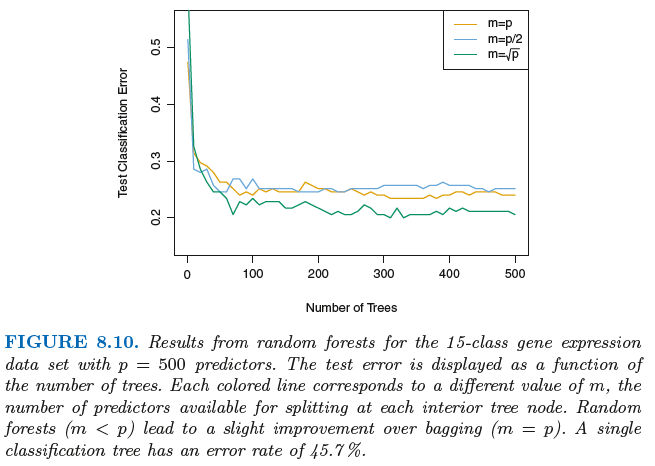

- Variable importance 산출
  - 해당 Feature가 tree에 포함된 경우와 제외된 경우의 예측정확도의 차이 또는 Gini impurity의 차이를 이용해 variable importance 계산

#### 스팸데이터 분석

```r
library(randomForest)
set.seed(5123512)
fmodel <- randomForest(x = spamTrain[,spamVars],
                       y = spamTrain$spam,
                       ntree = 100,
                       nodesize = 7,
                       importance = TRUE)
accuracyMeasures(predict(fmodel,
                         newdata = spamTrain[,spamVars],
                         type = 'prob')[,'spam'],
                 spamTrain$spam == "spam",
                 name = "random forest, train")
```

```
##                  model  accuracy        f1  dev.norm
## 1 random forest, train 0.9884142 0.9706611 0.1439711
```

```r
accuracyMeasures(predict(fmodel,
                         newdata = spamTest[,spamVars],
                         type = 'prob')[,'spam'],
                 spamTest$spam == "spam",
                 name = "random forest, test")
```

```
##                 model  accuracy        f1 dev.norm
## 1 random forest, test 0.9497817 0.8734057 0.301078
```

- Variable importance

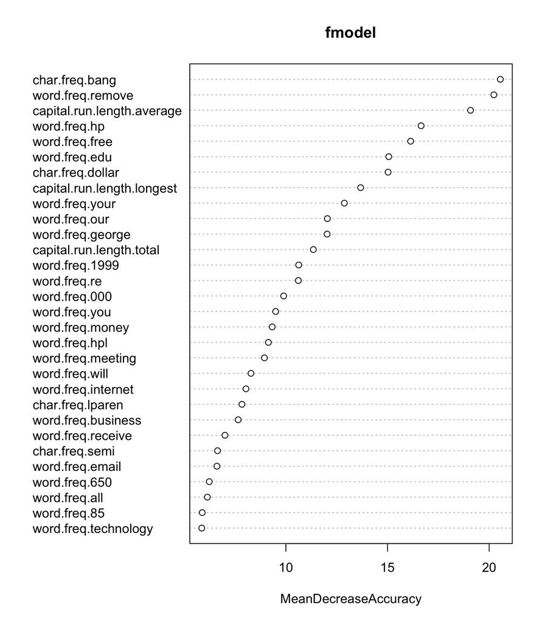

```r
varImpPlot(fmodel, type = 1)  # Accuracy
```

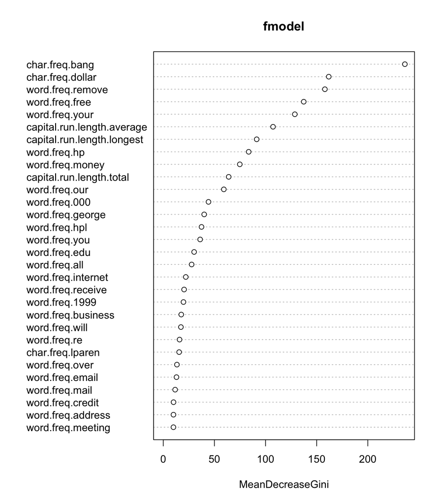

```r
varImpPlot(fmodel, type = 2)  # Gini
```

- Importance에 따라 feature selection

```r
varImp <- importance(fmodel, type = 2)
selVars <- names(sort(varImp[,1], decreasing = TRUE))[1:25]
fsel <- randomForest(x = spamTrain[,selVars],
                     y = spamTrain$spam,
                     ntree = 100,
                     nodesize = 7,
                     importance = TRUE)
accuracyMeasures(predict(fsel,
                         newdata = spamTrain[,selVars],
                         type = 'prob')[,'spam'],
                 spamTrain$spam == "spam",
                 name = "RF small, train")
```

```
##             model  accuracy      f1 dev.norm
## 1 RF small, train 0.9872073 0.96763 0.139925
```

```r
accuracyMeasures(predict(fsel,
                         newdata = spamTest[,selVars],
                         type = 'prob')[,'spam'],
                 spamTest$spam == "spam",
                 name = "RF small, test")
```

```
##            model  accuracy        f1  dev.norm
## 1 RF small, test 0.9519651 0.8786045 0.4136902
```

## 9.3 Ensemble method: Boosting

- 배깅의 경우 각 bootstrap sample 내의 모든 observation이 동일한 중요도를 가짐
- 부스팅은 잘못 분류된 observation에 높은 가중치를 부여하고 제대로 분류된 obs.에는 낮은 가중치를 부여해 학습을 반복 수행한 결과를 앙상블해 성능을 제고하는 방법임

### 9.3.1 Adaboost

- 반복의 각 단계에서 예측에 성공한 케이스의 가중치는 낮추고 틀린 케이스의 가중치는 높임
- 알고리즘
  1. 가중치를 $w_i=1/n$으로 초기화하고 $m=0$으로 둠
  2. Set $m \leftarrow m+1$. 현재 가중치를 이용해 분류기 $G_m(x)$ 학습
  3. 가중오류율 계산
     $${\rm err}_m = \frac{\sum_{i=1}^n w_iI(y_i \neq G_m(x_i) )}{\sum_{i=1}^n w_i}$$
  4. 모델가중치(신뢰도) 계산
     $$\alpha_m = \frac{1}{2}\log\left(\frac{1-{\rm err}_m}{{\rm err}_m}\right)$$
  5. 가중치 업데이트: 오분류된 obs.의 가중치에 $e^{\alpha_m}$을 곱하고 정분류된 obs.의 가중치에는 $e^{-\alpha_m}$을 곱한 뒤, 합이 1이 되도록 normalize
  6. Step 2 - 5를 $M$번 반복해 $M$개의 분류기를 만듬
  7. 최종 앙상블 분류기:
     $$G(x) = {\rm sgn}\left(\sum_{m=1}^M \alpha_m G_m(x)\right)$$

#### 예제 데이터 분석

- 스팸데이터 분석

```r
n.tr <- nrow(spamTrain)
n.test <- nrow(spamTest)
w <- rep(1, n.tr)/n.tr
M <- 20
G.tr <- matrix(NA, M, n.tr)
G.test <- matrix(NA, M, n.test)
alpha <- rep(NA, M)
for ( m in 1:M ) {
  treemodel <- rpart(spamFormula, data = spamTrain, weights = w)
  pred.tr <- predict(treemodel, newdata = spamTrain) >= 0.5
  pred.test <- predict(treemodel, newdata = spamTest) >= 0.5
  p.tr <- rep("non-spam", n.tr)
  p.test <- rep("non-spam", n.test)
  p.tr[pred.tr] <- "spam"
  p.test[pred.test] <- "spam"
  G.tr[m, ] <- p.tr
  G.test[m, ] <- p.test
  err <- sum(w[p.tr != spamTrain$spam])/sum(w)
  alpha[m] <- .5*log(min(1 - err, 1 - 1e-6)/max(err, 1e-6))
  w[p.tr == spamTrain$spam] <- w[p.tr == spamTrain$spam]*exp(-alpha[m])
  w[p.tr != spamTrain$spam] <- w[p.tr != spamTrain$spam]*exp(alpha[m])
  w <- w/sum(w)
}
print(alpha)
```

```
##  [1] 1.15957929 0.83580492 0.79249037 0.78060177 0.80883428 0.65320312
##  [7] 0.71342301 0.61586531 0.65357605 0.69715075 0.52724927 0.54355108
## [13] 0.46599207 0.54445722 0.36774458 0.33212760 0.30622458 0.17263570
## [19] 0.06294804 0.36450996
```

```r
alpha.tr <- matrix(alpha, M, n.tr, byrow = TRUE)
alpha.test <- matrix(alpha, M, n.test, byrow = TRUE)

accuracyMeasures(colSums(alpha.tr*(2*(G.tr == "spam") - 1)) > 0,
                 spamTrain$spam == "spam",
                 name = "adaboost, train")
```

```
##             model accuracy        f1  dev.norm
## 1 adaboost, train 0.989621 0.9738495 0.5735623
```

```r
accuracyMeasures(colSums(alpha.test*(2*(G.test == "spam") - 1)) > 0,
                 spamTest$spam == "spam",
                 name = "adaboost, test")
```

```
##            model  accuracy        f1 dev.norm
## 1 adaboost, test 0.9366812 0.8421378 3.499126
```

- 한계점
  - Weak learner가 너무 복잡한 모형이거나 예측력이 너무 약하면 성능이 저하됨

### 9.3.2 Functional gradient boosting algorithm

- Friedmann et al. (2000), Friedmann (2001): 부스팅을 함수추정 문제 관점, 즉
  $$E \left\{L(f({\mathbf X}), Y)\right\}$$
  을 최소로 만드는 함수 $f$를 찾는 문제로 생각할 수 있음
- Empirical version:
  $$n^{-1}\sum_{i=1}^n L(f(x_i), y_i)$$
- Gradient descent algorithm
  - 손실함수(loss function)를 $L(f_\theta({\mathbf X}), Y)$로, 학습률(learning rate)을 $\eta$로 나타내면
    $$\theta^{(1)} = \theta^{(0)} - \eta\cdot\frac{\partial}{\partial\theta}E L(f_\theta({\mathbf X}), Y)$$
    와 같은 업데이트 룰에 따라 학습
- Generic FGD algorithm
  1. Initialize ${\hat f}^{(0)}(\cdot)$ with an offset value
     $${\hat f}^{(0)}(\cdot) = \arg\min_c \,\,\frac{1}{n}\sum_{i=1}^n L(c, y_i)$$
     and set $m=0$.
  2. Set $m = m+1$. Compute the negative gradient $-\frac{\partial}{\partial f} L(f, y)$ and evaluate at ${\hat f}^{(m-1)}(x_i)$:
     $$U_i = -\frac{\partial}{\partial f}L(f, y_i)\Big|_{f = {\hat f}^{(m-1)}(x_i)},\quad i=1,2,...,n$$
  3. Fit $U_i$’s to $x_i$’s by the base procedure (e.g. regression).
     $$(x_i, U_i)_{i=1}^n \stackrel{\rm base\,\, procedure}{\longrightarrow} \hat{g}^{(m)}(\cdot)$$
     $\hat{g}^{(m)}(\cdot)$ can be viewed as an approximation of the negative gradient vector.
  4. Update:
     $${\hat f}^{(m)}(\cdot) = {\hat f}^{(m-1)}(\cdot) + \eta\, {\hat g}^{(m)}(\cdot)$$
  5. Iterate steps 2 to 4 until $m = M$.
- 이항 분류문제에서 Adaboost 알고리즘은 손실함수가 $L(f, y) = \exp(-(2y-1)f)$인 경우에 해당함 (Breiman, 1998, 1999)

#### 예제 데이터 분석: 스팸데이터

- `gbm` 패키지 사용

```r
library(gbm)
```

- 학습

```r
boostedTree <- gbm(spamFormula, data = spamTrain,
                   distribution = "bernoulli",
                   cv.folds = 5, n.trees = 5000)
```

- `distribution` 옵션: 손실함수 $L$을 지정하는 옵션임
  - “gaussian” (squared error), “laplace” (absolute loss), “bernoulli” (logistic regression for 0-1 outcomes), “multinomial” (classification when there are more than 2 classes), “adaboost” (the AdaBoost exponential loss for 0-1 outcomes), and so on

```r
best.iter <- gbm.perf(boostedTree, method = "cv")
```

[figure not shown]

```r
pred <- predict(boostedTree, spamTrain, best.iter)
print(ctableTrain <- table(pred > 0, spamTrain$spam == "spam"))
```

```
##
##         FALSE TRUE
##   FALSE  2451   96
##   TRUE     59 1537
```

```r
print(accuracyTrain <- sum(diag(ctableTrain))/sum(ctableTrain))
```

```
## [1] 0.9625875
```

```r
pred <- predict(boostedTree, spamTest, best.iter)
print(ctableTest <- table(pred > 0, spamTest$spam == "spam"))
```

```
##
##         FALSE TRUE
##   FALSE   268   15
##   TRUE     10  165
```

```r
print(accuracyTest <- sum(diag(ctableTest))/sum(ctableTest))
```

```
## [1] 0.9454148
```

### 9.3.3 XGBoost

- E**x**treme **g**radient **boost**ing
- Gradient boosting 의 속도 문제를 병렬 처리를 통해 획기적으로 개선
- 결측치 처리, 데이터 imbalance 문제, variable importance 문제 등에 대응

#### 예제데이터 분석

- 데이터 준비

```r
library(xgboost)

spamTrainLabel <- 1*(spamTrain$spam == "spam")
XTrain <- data.matrix(spamTrain[, spamVars])
DTrain <- xgb.DMatrix(data = XTrain, label = spamTrainLabel)

spamTestLabel <- 1*(spamTest$spam == "spam")
XTest <- data.matrix(spamTest[, spamVars])
DTest <- xgb.DMatrix(data = XTest, label = spamTestLabel)

watchlist <- list(train = DTrain, test = DTest)
```

- 학습

```r
bst <- xgb.train(data = DTrain,
                 nrounds = 3,
                 watchlist = watchlist,
                 objective = "binary:logistic")
```

- `objective` 지정 방법
  - `reg:linear`: linear regression (Default).
  - `reg:logistic`: logistic regression.
  - `binary:logistic`: logistic regression for binary classification. Output probability.
  - `binary:logitraw`: logistic regression for binary classification, output score before logistic transformation.
  - `num_class` set the number of classes. To use only with multiclass objectives.
  - `multi:softmax` set xgboost to do multiclass classification using the softmax objective. Class is represented by a number and should be from 0 to `num_class` - 1.
  - `multi:softprob` same as softmax, but prediction outputs a vector of ndata * nclass elements, which can be further reshaped to ndata, nclass matrix. The result contains predicted probabilities of each data point belonging to each class.
- 튜닝 & 학습

```r
bst <- xgb.train(data = DTrain,
#                nthread = 3,
                 max_depth = 10, nrounds = 10000,
                 watchlist = watchlist,
                 early_stopping_rounds = 30, maximize = FALSE,
                 print_every_n = 10,
                 scale_pos_weight = sum(spamTrainLabel == 0)/sum(spamTrainLabel == 1),
                 objective = "binary:logistic")
```

[output not shown]

- 예측 & 평가

```r
pred <- predict(bst, XTrain)
accuracyMeasures(pred,
                 spamTrain$spam == "spam",
                 name = "XGboost, train")
```

```
##        pred
## truth   FALSE TRUE
##   FALSE  2495   15
##   TRUE     27 1606
```

```
##            model  accuracy        f1  dev.norm
## 1 XGboost, train 0.9898624 0.9743655 0.1025984
```

```r
pred <- predict(bst, XTest)
accuracyMeasures(pred,
                 spamTest$spam == "spam",
                 name = "XGboost, test")
```

```
##        pred
## truth   FALSE TRUE
##   FALSE   269    9
##   TRUE      8  172
```

```
##           model  accuracy        f1  dev.norm
## 1 XGboost, test 0.9628821 0.9080417 0.2536956
```

- Variable importance

```r
importance <- xgb.importance(feature_names = spamVars, model = bst)
head(importance, n = 10)
```

```
##                        Feature       Gain      Cover  Frequency
##  1:             char.freq.bang 0.30661887 0.08480649 0.06579634
##  2:           word.freq.remove 0.12222193 0.06262666 0.01984334
##  3:           char.freq.dollar 0.09227050 0.05574595 0.02402089
##  4: capital.run.length.average 0.06298928 0.04657945 0.07519582
##  5:               word.freq.hp 0.04967237 0.05635230 0.02819843
##  6:             word.freq.free 0.04780071 0.03938617 0.04125326
##  7: capital.run.length.longest 0.03521859 0.04361292 0.06005222
##  8:           word.freq.george 0.03050735 0.05693419 0.01984334
##  9:   capital.run.length.total 0.02682609 0.05334431 0.08720627
## 10:              word.freq.edu 0.02418581 0.04865928 0.02819843
```

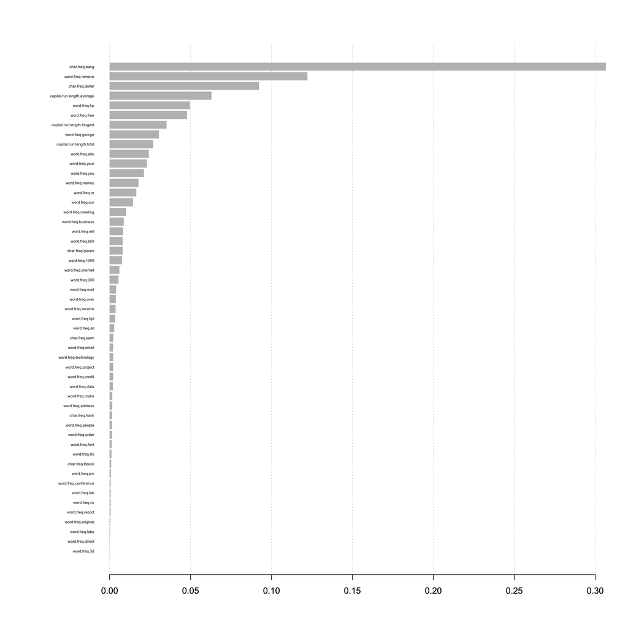

```r
xgb.plot.importance(importance_matrix = importance)
```

- Random Forest와 결합

```r
bst <- xgb.train(data = DTrain,
                 max_depth = 10, nrounds = 10000,
                 watchlist = watchlist,
                 early_stopping_rounds = 30, maximize = FALSE,
                 print_every_n = 10,
                 subsample = 0.5, colsample_bytree = 0.5,
                 num_parallel_tree = 1000,
                 scale_pos_weight = sum(spamTrainLabel == 0)/sum(spamTrainLabel == 1),
                 objective = "binary:logistic")
```

[output not shown]

```r
pred <- predict(bst, XTrain)
accuracyMeasures(pred,
                 spamTrain$spam == "spam",
                 name = "XGboost_RF, train")
```

```
##               model  accuracy        f1  dev.norm
## 1 XGboost_RF, train 0.9855177 0.9635736 0.1365049
```

```r
pred <- predict(bst, XTest)
accuracyMeasures(pred,
                 spamTest$spam == "spam",
                 name = "XGboost_RF, test")
```

```
##              model  accuracy        f1  dev.norm
## 1 XGboost_RF, test 0.9628821 0.9066984 0.2438714
```

```r
importance <- xgb.importance(feature_names = spamVars, model = bst)
head(importance, n = 10)
```

```
##                        Feature       Gain      Cover  Frequency
##  1:             char.freq.bang 0.17149288 0.06836348 0.06560877
##  2:           char.freq.dollar 0.09668840 0.04118547 0.02088141
##  3:           word.freq.remove 0.07710961 0.04107848 0.01536087
##  4: capital.run.length.average 0.06440057 0.06990883 0.10107695
##  5:             word.freq.free 0.05717265 0.03832319 0.03092884
##  6:               word.freq.hp 0.05216678 0.04458402 0.01876792
##  7: capital.run.length.longest 0.04986056 0.05321721 0.07441244
##  8:   capital.run.length.total 0.04627866 0.06241227 0.10115390
##  9:             word.freq.your 0.04425791 0.03680034 0.05319378
## 10:           word.freq.george 0.03313196 0.03871083 0.01174954
```

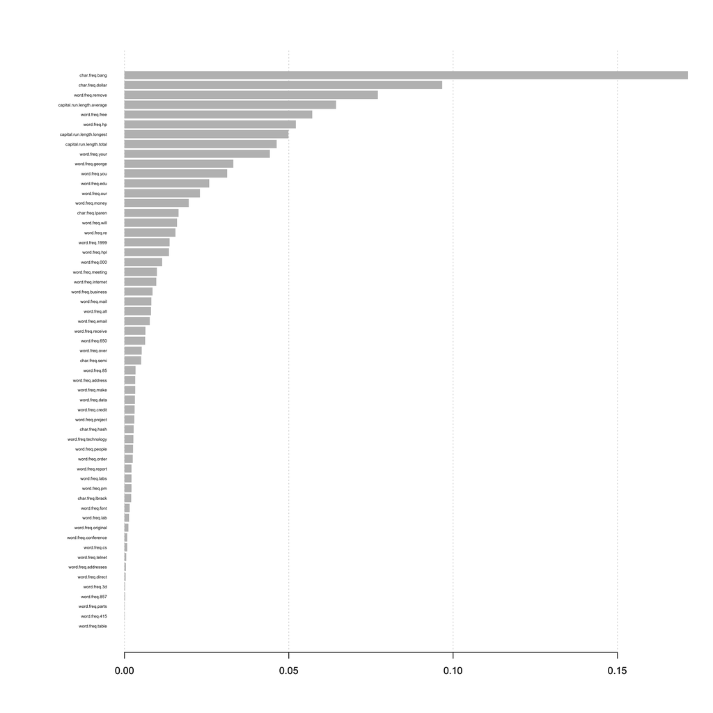

```r
xgb.plot.importance(importance_matrix = importance)
```